# ROC Curve

103304029 Harry Liou

At first, I will demonstrate the codes of plotting the “ROC Curve” and “area under the curve (auc)” below.

```r
d1 = rnorm(100, 0, 1)
d2 = rnorm(100, 1, 1)
d3= c(d1,d2) %>% sort()

tpf=c();fpf=c()
for(n in 1:length(d3)){
  c=d3[n]
  a1=mean(1*(d1<c))
  a2=mean(1*(d2<c))
  tpf=c(tpf,a1)
  fpf=c(fpf,a2)
}

par(mfrow=c(1,2))
plot(density(d1),xlim=c(-5, 5),ylim=c(0,0.5),xlab = "value",col="red")
lines(density(d2),col="blue")
plot(fpf,tpf,xlab = "fpf",ylab = "tpf",main = "ROC Curve",type="l")

auc=0
for(n in 1:(length(tpf)-1)){
  a=(tpf[n+1])*(fpf[n+1]-fpf[n])
  auc = auc + a
}
paste("auc = ", auc)
```

d1, d2 mean data1, data2 randomly generated observations following normal dostrobution. tpf and fpf mean True Positive Fraction and False Positive Fraction calculated by the ratio of obeservaitions under the specific cut-point. The x-axis and y-axis mean the fpf and tpf for all cut-points. auc means the “area under the ROC curve”, usually presenting the goodness of our classification.

Now, we try the data which both have 100 observations, one follow N(0,1), and one follow N(1,1).

```r
d1 = rnorm(100, 0, 1)
d2 = rnorm(100, 1, 1)
```

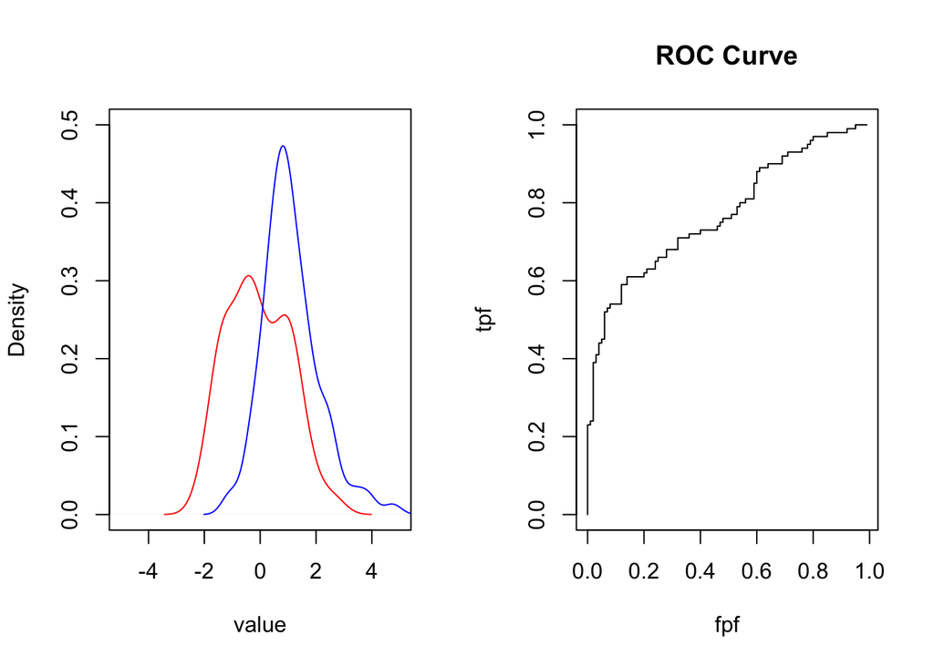

```
## [1] "auc =  0.7616"
```

In the first figure, the red line is data1, the blue line is data2. We can see that roc curve is separated. If we increase the observations, the curve will be more soomth. So, we try the data which both have 1000 observations, one follow N(0,1), and one follow N(1,1).

```r
d1 = rnorm(1000, 0, 1)
d2 = rnorm(1000, 1, 1)
```

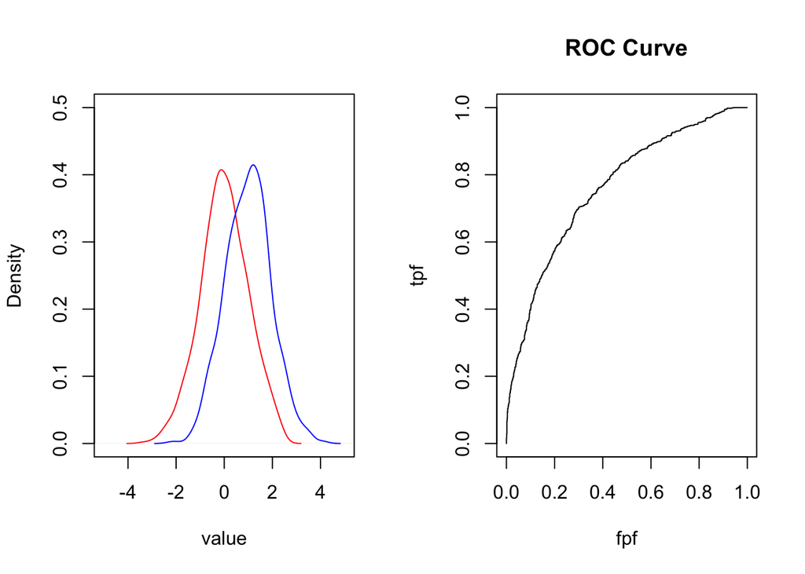

```
## [1] "auc =  0.759939000000001"
```

If you try more data following the same distrobution, the curve will be more smoother. Now we set two data more separately, one follow N(-2,1), and one follow N(2,1).

```r
d1 = rnorm(1000, -2, 1)
d2 = rnorm(1000, 2, 1)
```

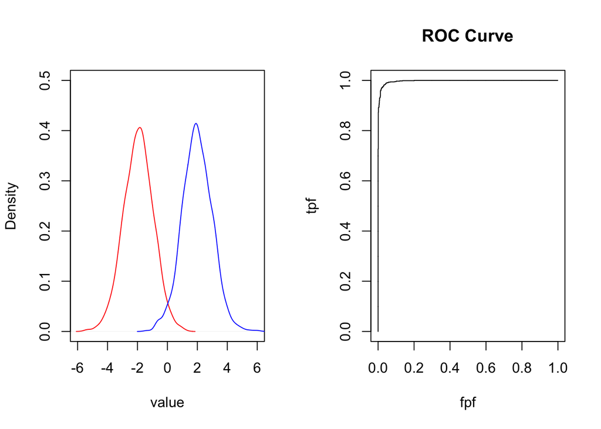

```
## [1] "auc =  0.996359"
```

In the first figure, we can obtain that two distribution are more separately. In the second figure, we can see the “ROC Curve” become more full. “auc” is more big than former two, which means that we can classificate better on more separated data sets.

Now we can try the case which has different variance. Let’s compare four situations: N(-1,1) v.s. N(1,1) N(-1,2) v.s. N(1,1) N(-1,1) v.s. N(1,2) N(-1,2) v.s. N(1,2) They have same mean but designed variance.

First one is our standard one, which has beautiful symmetry two distributions and the ROC Curve.

```r
d1 = rnorm(1000, -1, 1)
d2 = rnorm(1000, 1, 1)
```

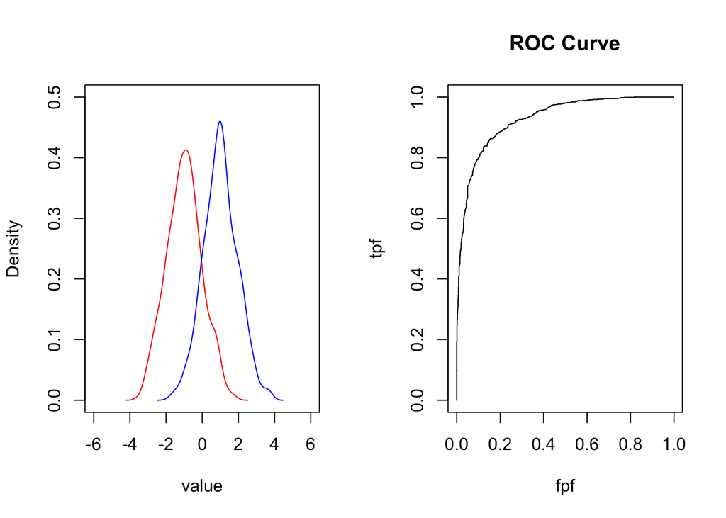

```
## [1] "auc =  0.927198999999998"
```

From second one’s first figure we can obtain that there is a huge area has only red (value -6~-2), but blue increase rapidly then (value -2~1). So we can see that the “ROC Curve” raises rapidly, lately reaches the 0.8, 0.9 tpf.

```r
d1 = rnorm(1000, -1, 2)
d2 = rnorm(1000, 1, 1)
```

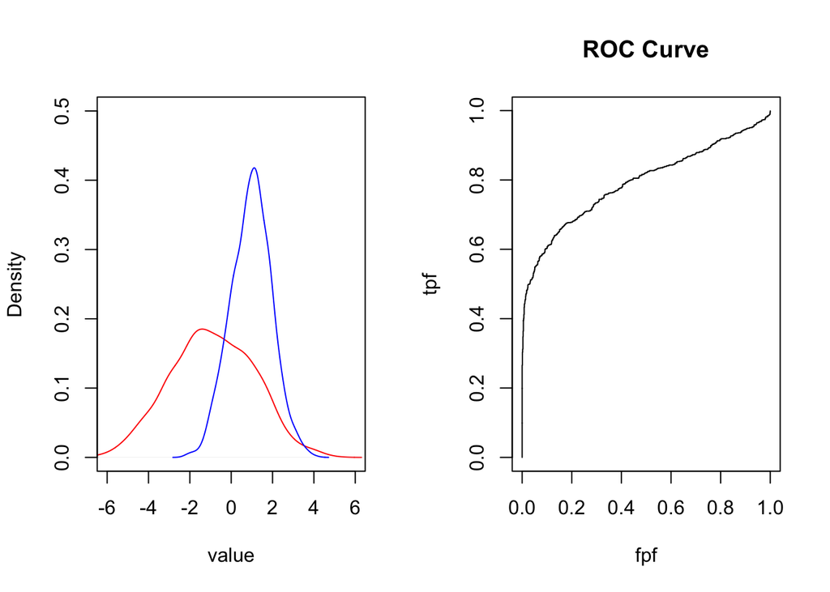

```
## [1] "auc =  0.791914000000001"
```

From third one’s first figure we can obtain that blue penetrate red from vary small value(-6), but cannot cover red when value is bigger than 2, as there is no red anymore. So we can see that the “ROC Curve” raises slowly at first, reaches the 0.8, 0.9 tpf quicker than the second situation.

```r
d1 = rnorm(1000, -1, 1)
d2 = rnorm(1000, 1, 2)
```

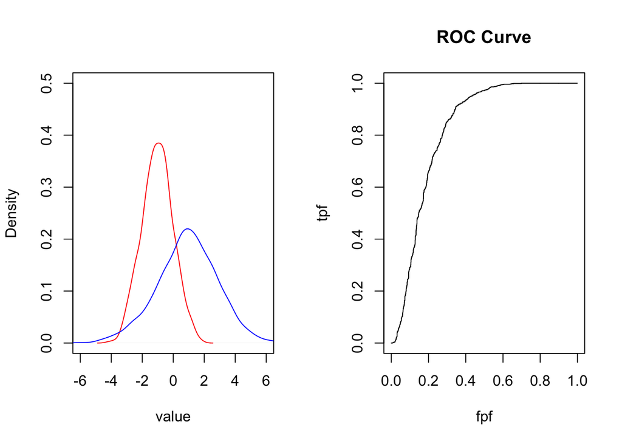

```
## [1] "auc =  0.817159"
```

From fourth one’s first figure we can found that two distributions are hard to tell apart, so we can see the roc cure is closer to the diagonal, and the “auc” is lower.

```r
d1 = rnorm(1000, -1, 2)
d2 = rnorm(1000, 1, 2)
```

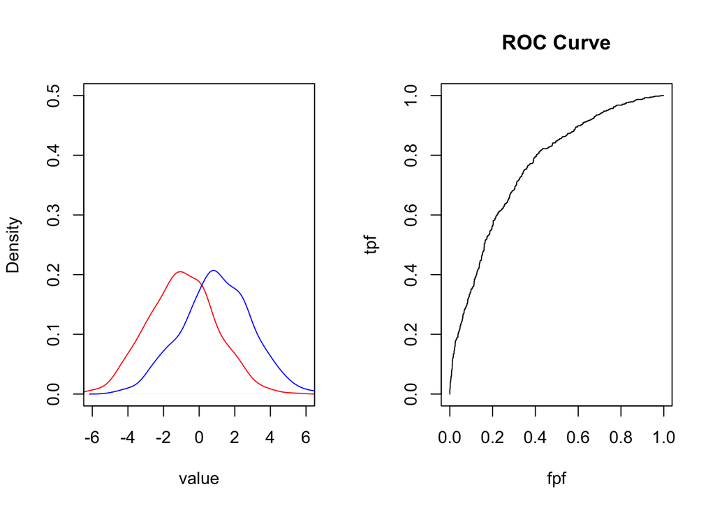

```
## [1] "auc =  0.758548999999999"
```

Now I want to try the unbalanced data, one has 500 observations folowing N(-1,1), one has 10000 observations following N(1,1). Let’s see what happened.

```r
d1 = rnorm(500, -1, 1)
d2 = rnorm(10000, 1, 1)
```

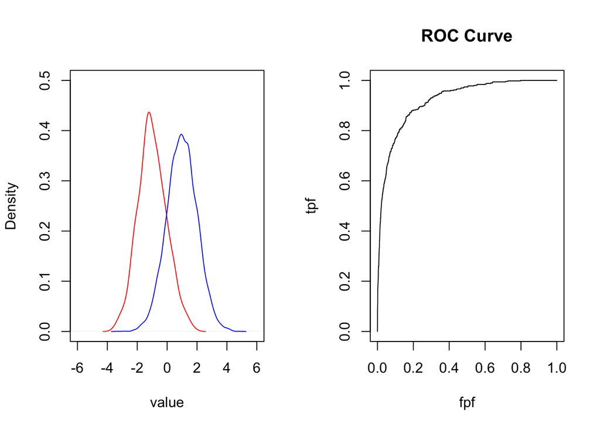

```
## [1] "auc =  0.920566399999952"
```

In fact, nothing happened! The unbalanced data didn’t affect the “ROC Curve”, because the x-axis and y-axis is True Positive Fraction and False Positive Fraction! Fracttion/ratio won’t change by reason of sample size, and it’s really a useful property.

Last but not least, I want to discuss why “auc” is important for the ROC Curve. The ROC Curve presents all cut-points, but which cut-point is the best is the key we want to know.

The following is my opinion: A good cut-point must have both high tpf and low fpf, and this promises that big area under the ROC Curve because the curve is monotone. (if a ROC Curve pass through the point (0.2,0.8), the point promises that the “auc” will be at least 0.64.) logically, small “auc” implies that any point of the ROC Curve couldn’t have really high tpf and really low fpf simultaneously.